# Differential expression analysis of the Hayman and Paschricha (C084) iron study

Peter Hickey https://peterhickey.org (WEHI SCORE)https://www.wehi.edu.au/people/shalin-naik/3310/score  
2020-08-07

# Setting up the data

We start from the count matrices created in `code/scPipe.R`, specifically the UMI counts (a.k.a. UMI-deduplicated) data and read counts (a.k.a. not UMI-deduplicated) data.

UMI stands for unique molecular identifier.

We combine these into a single object[^1] containing both the UMI counts and the read counts for 32857 genes and 588 samples.

## Incorporating gene-based annotation

We obtain gene-based annotations from the NCBI/RefSeq and Ensembl databases, such as the chromosome and gene symbol, using the *Homo.sapiens* and *EnsDb.Hsapiens.v86* packages.

Having quantified gene expression against the GENCODE gene annotation, we have Ensembl-style identifiers for the genes. These identifiers are used as they are unambiguous and highly stable. However, they are difficult to interpret compared to the gene symbols which are more commonly used in the literature. Henceforth, we will use gene symbols (where available) to refer to genes in our analysis and otherwise use the Ensembl-style gene identifiers[^2].

## Incorporating sample-based annotation

**TODO**: Incorporate updated sample sheet.

# Failure of `LCE475`

There are 3 batches of samples in total - LCE475, C084_LC475_mini_bulk_back_up_1:10, and LCE_476_BU_8_cycle - and these are technical replicates of one another (i.e. each well contains the same sample across all 3 batches). However, this was not the original plan.

The `LCE475` batch was intended to be the only batch, but something went wrong in the library preparation and it generated very few reads (maximum library size in reads = 1960). Likely what happened, according to Daniel Brown, is that there was carry-over of a large number of molecules without adapters, which meant that the `LCE475` library contained few sequence-able molecules. We therefore remove the `LCE475` samples from further analysis.

Following the failure of `LCE475`, the library preparation and sequencing were repeated a further 2 times:

- `C084_LC475_mini_bulk_back_up_1:10`: **TODO** Get description of what was done to this plate.
- `LCE_476_BU_8_cycle`: **TODO** Get description of what was done to this plate.

These two plates are essentially technical replicates.

# Have we sequenced enough?

## Motivation

**TODO**: Spiel about whether we’ve sequenced enough.

## Analysis

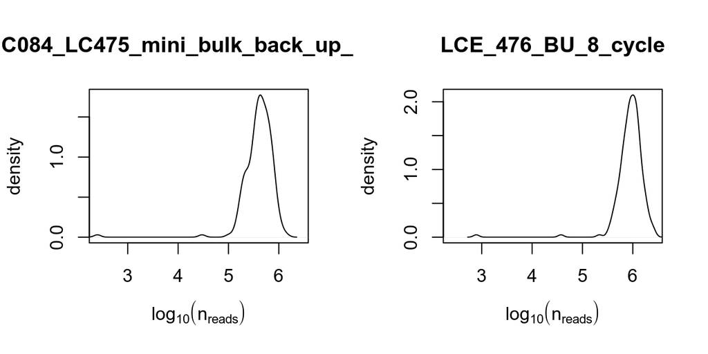

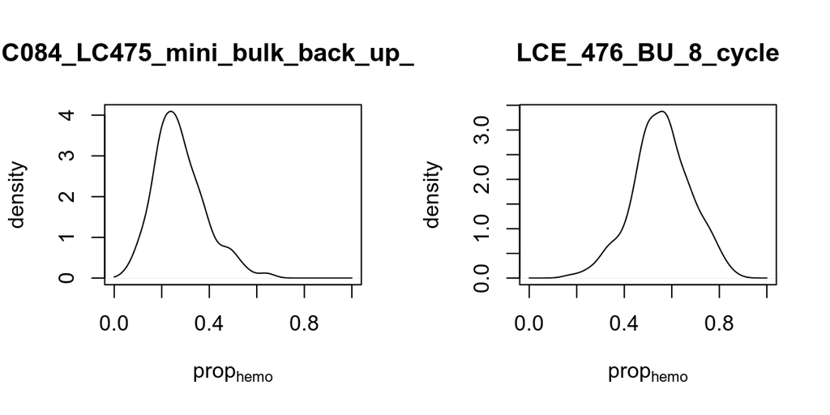

10X use a [formula to quantify the sequencing saturation](https://kb.10xgenomics.com/hc/en-us/articles/115003646912-How-is-sequencing-saturation-calculated-):

> 1 - (n_deduped_reads / n_reads)

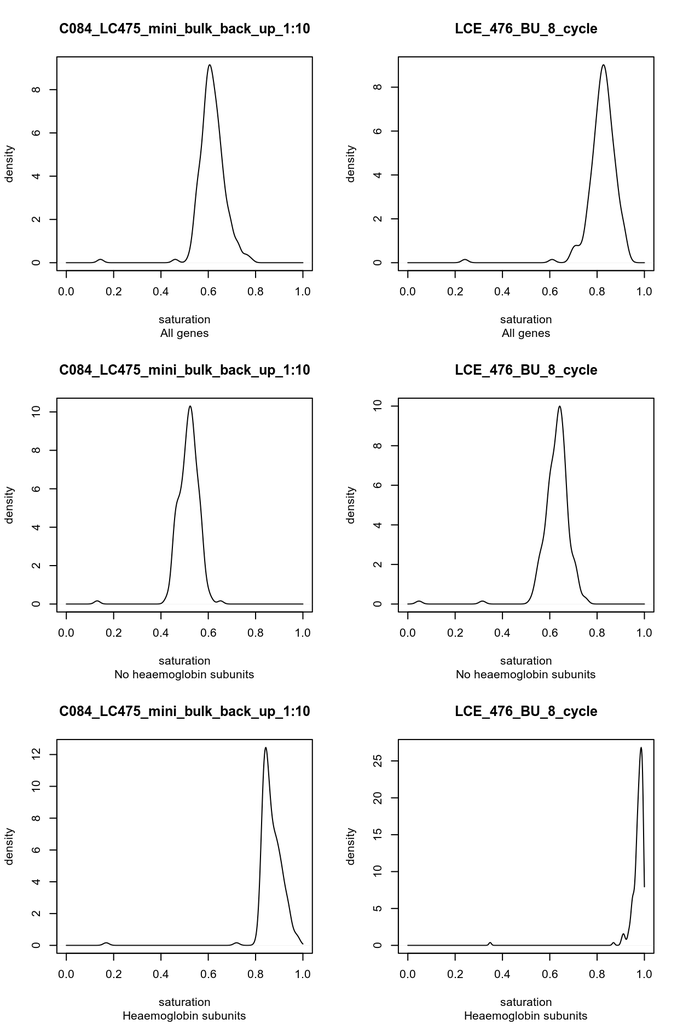

# UMI counts vs. read counts

## Motivation

A unique feature of SCORE’s ‘mini-bulk’ RNA-sequencing protocol is the incorporation of unique molecular identifiers (UMIs) into the library preparation; an ordinary bulk RNA-seq protocol does not incorporate UMIs.

UMIs are commonly used in single-cell RNA-sequencing protocols, such as the CEL-Seq2 protocol from which the mini-bulk protocol is adapted. UMIs are molecular tags that are used to detect and quantify unique mRNA transcripts. In this method, mRNA libraries are generated by fragmentation and reverse-transcribed to cDNA. Oligo(dT) primers with specific sequencing linkers are added to the cDNA. Another sequencing linker with a 6 bp random label and an index sequence is added to the 5’ end of the template, which is amplified and sequenced.

This explanation is adapted from https://sapac.illumina.com/science/sequencing-method-explorer/kits-and-arrays/umi.html.

The UMI count is always less than or equal to the read count and a UMI count of zero also implies a read count of zero.

Pros of using UMIs:

- Can sequence unique mRNA transcripts
- Can detect transcripts occurring at low frequencies
- Transcripts can be quantified based on sequencing reads specific to each barcode

Cons of using UMIs:

- SCORE’s mini-bulk protocol uses a $k=6$ bp UMI[^3] and so (theoretically) the maximum UMI count for each gene is $4^6 = 4096$.
- There is therefore a risk that highly expressed genes may have their expression measurements artificially truncated, particularly if the sample is deeply sequenced.

To investigate whether expression measurements are being ‘truncated’ in this dataset, and decide whether to use the UMI counts or the read counts, we generated and now analyse two count matrices:

1. UMI counts (i.e. deduplicating UMI counts)
2. Read counts (i.e. not deduplicating UMI counts, equivalent to ignoring the UMIs)

## Analysis

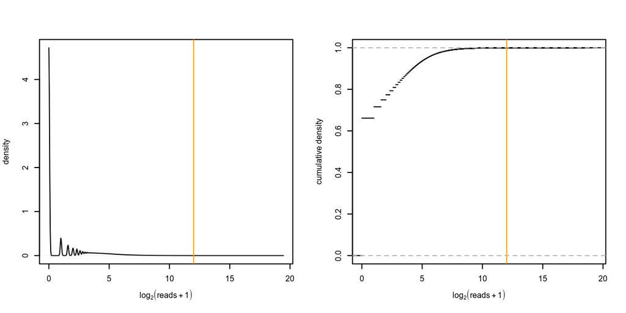

Figure 1: Distribution of the logarithm of the read counts as density plot (left) and empirical cumulative distribution function (right). A count of 1 is added to each UMI count to avoid taking the logarithm of zero. The orange vertical line denotes $4^6 = 4096$.

Figure 1 plots the distribution of the logarithm of the read counts. From this we see that the vast majority of read counts are small. In fact:

- 66.1% of read counts are 0
- 95% of the read counts are no greater than 41
- 99% of the read counts are no greater than 179
- 99.9% of the read counts are no greater than 1074

Most importantly, only (0.018%) of read counts exceed the $4^6=4096$ threshold.

Surprisingly, 0.004% of UMI counts exceed the theoretical maximum of $4^6=4096$. At this stage it is not clear to me how this can occur.

The only genes with read counts exceeding the $4^6=4096$ threshold are shown in the table below. If we were to use the UMI counts, the genes in this list will have their expression measurements artificially truncated in those samples where the read counts exceed the $4^6=4096$ threshold.

[interactive table not shown]

There are a few points worth drawing attention to based on this table:

1. The 3 worst offenders are all haemoglobin subunits
2. There are several mitochondrial and ribosomal protein genes on the list
3. There are some key immune genes on the list, e.g., *PTPRC* (encoding CD45), *B2M*, and *HLA-B*

We can investigate this list more formally using a statistical test for over-representation of gene ontology (GO) terms in this gene set. This is done using the `goana()` function from the *limma* package. These results are shown in the table below.

|  | Term | Ont | N | DE | P.DE |
| --- | --- | --- | --- | --- | --- |
| GO:0006950 | response to stress | BP | 4042 | 27 | 3.71098964358971e-12 |
| GO:0031720 | haptoglobin binding | MF | 10 | 4 | 1.87516295778333e-09 |
| GO:0031838 | haptoglobin-hemoglobin complex | CC | 11 | 4 | 2.94288722877484e-09 |
| GO:0005833 | hemoglobin complex | CC | 12 | 4 | 4.40864213035746e-09 |
| GO:0006119 | oxidative phosphorylation | BP | 145 | 7 | 6.62716635926703e-09 |
| GO:0005737 | cytoplasm | CC | 11311 | 36 | 8.62090207609652e-09 |
| GO:0005344 | oxygen carrier activity | MF | 14 | 4 | 8.89229131523214e-09 |
| GO:0098803 | respiratory chain complex | CC | 85 | 6 | 8.93929043502433e-09 |
| GO:0015671 | oxygen transport | BP | 15 | 4 | 1.21102259280554e-08 |
| GO:0042775 | mitochondrial ATP synthesis coupled electron transport | BP | 97 | 6 | 1.98851562186189e-08 |

[output cut: 876 more lines]

Several of the top GO terms relate to haptoglobin and hemoglobin, mitochondrial functions, and immune terms. However, it is somewhat concerning to see ‘response to stress’ at the top of this list, which may indicate the sample quality was compromised prior to or during library preparation.

Figure 2 plots the relationship between UMI counts and read counts for all genes and samples.

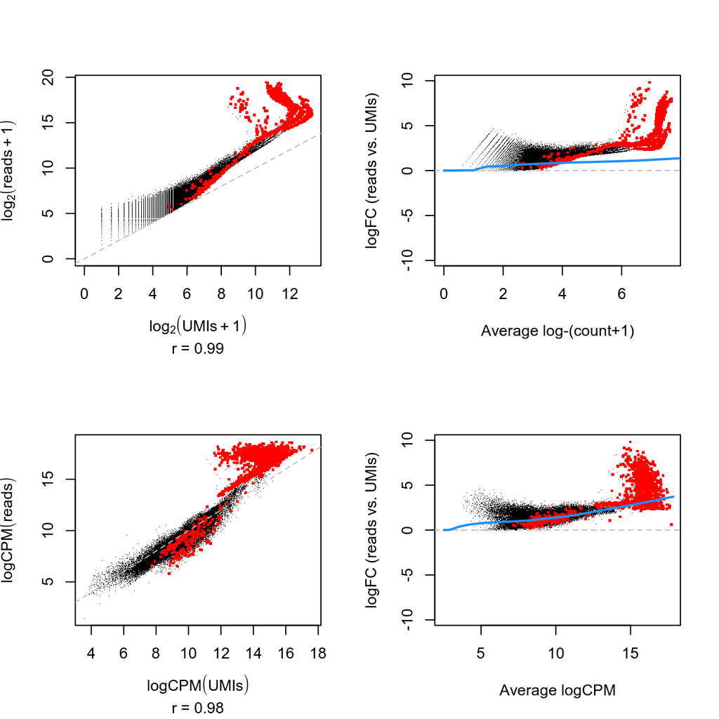

There are a few notable points about this figure:

1. The UMI counts and read counts are very strongly associated.
2. The log-fold change between the read counts and the UMI counts can be large, indicating the UMI counts are likely removing substantial PCR amplification noise.
3. The log-fold changes between the read counts and the UMI counts are larger on average for more highly expressed genes. The variation in the log-fold change is larger for the lowly expressed genes.
4. The haemoglobin genes stand out. These genes are extremely highly expressed, meaning that they likely saturate the 6 bp UMIs and which leads to the strange relationship between the UMI counts and the read counts for these genes.

Rather than looking at all samples and all genes at once, can also examine the relationship between UMI counts and read counts within a single sample across genes (Figure 3) and within a single gene across samples (Figure 4).

These figures show that the UMI counts and read counts are highly correlated across both samples (median = 0.99, median absolute deviation = 0) and genes (median = 0.97, median absolute deviation = 0.03).

The genes with the lowest correlations are the aforementioned highly-expressed haemoglobin subunits.

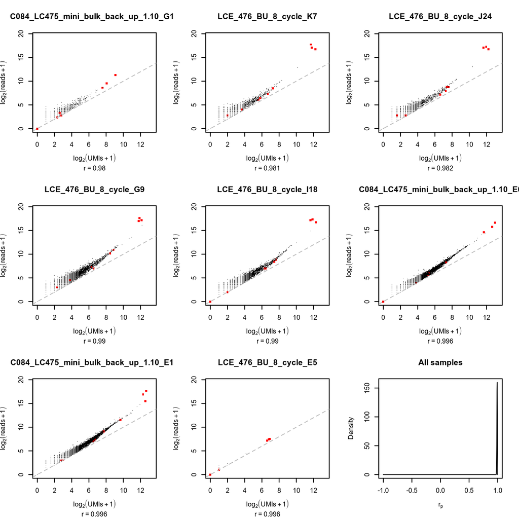

Figure 3: Association between UMI counts and read counts for each gene within each sample. The first 8 panels are scatter plots of the UMI counts and read counts for each gene for the samples with the 3 lowest correlations, 2 middlemost correlations, and 3 highest correlations. The correlation in the scatterplot is reported below each panel. The final panel is the distribution of these correlations across all samples.

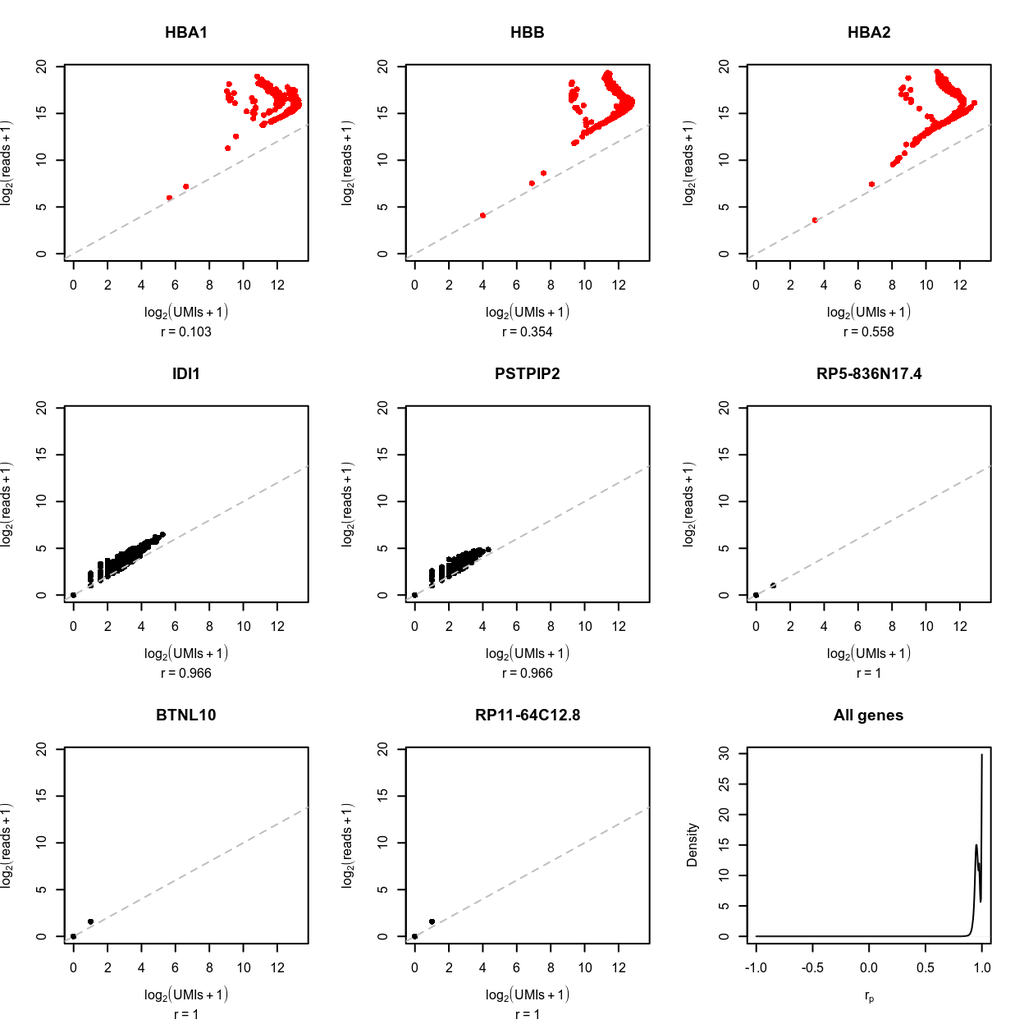

Figure 4: Association between UMI counts and read counts for each sample within each gene. The first 8 panels are scatter plots of the UMI counts and read counts for each sample for the genes with the 3 lowest correlations, 2 middlemost correlations, and 3 highest correlations. The correlation in the scatterplot is reported below each panel. The final panel is the distribution of these correlations across all genes.

## Summary

As there are so few read counts that exceed the threshold of $4^6 = 4096$ there is little risk that the expression measurements are artificially truncated by using the UMI counts. Additionally, compared to the read counts, the UMI counts have the advantage that they mitigate the effects of PCR amplification noise. We therefore opt to use the UMI counts in all the analysis the follows.

# Quality control of samples

- Danny and Daniel expect the plate with more PCR will have more genes

## Batch effect stuff

**TODO** Move this to after QC.

### Motivation

**TODO**: Were the 2 `plate_number` separate library preps or is one a re-sequenced technical replicate? That is, might there be double counting of UMIs across `plate_number`?

### Analysis

Figure 5 plots the relationship between the log-counts per million (logCPM) of the UMI counts in each batch for all genes and samples at the sample level and aggregated at the plate level.

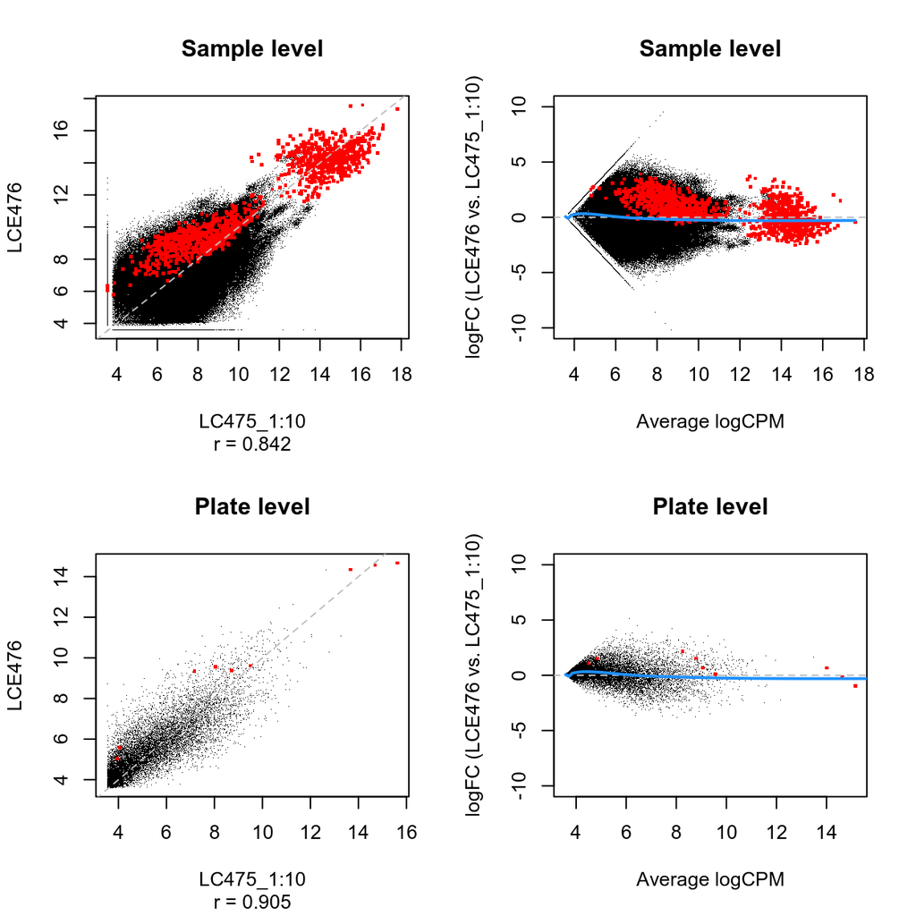

Figure 5: Scatterplot of the logCPM of the UMI counts in each batch for all genes and samples (left) and mean-difference plot of the same data (right) as the sample level (top) and aggregated at the plate level (bottom). The correlation in the scatterplot is reported below the x-axis label. Genes that are haemoglobin subunits are highlighted in red. The blue line is a trend fitted to the mean-differences.

There are a few notable points about this figure:

1. The UMI counts in each batch are strongly associated.
2. The majority of log-fold changes between batches are small at both the sample and plate levels.
   1. At the sample level, 72% UMI counts have $|logFC| < 0.5$ between batches and only $5\%$ of UMI counts have $|logFC| >$ 1.67.
   2. At the plate level, 81% UMI counts have $|logFC| < 0.5$ between batches and only $5\%$ of genes have $|logFC| >$ 1.29.
3. The haemoglobin subunit genes with lower average expression appear more highly expressed in the `LCE476` plate, whereas those haemoglobin subunit genes with higher average expression appear to not be differentially expressed.

Rather than looking at all samples and all genes at once, can also examine the relationship of UMI counts between batches within a single sample across genes (Figure 6) and within a single gene across samples (Figure 7).

These figures show that the logCPM of the UMI counts are highly correlated within a sample across genes (median = 0.85, median absolute deviation = 0.02) but almost uncorrelated within a gene across samples (median = 0.03, median absolute deviation = 0.1). The average lack of correlation within each gene across samples is often due to a minority of samples with very discordant UMI counts in each batch and the overall sparsity of counts for the majority of genes. If we focus on the $n=$ 1986 genes (6.0%) detected in at least $99\%$ of samples, then the correlation increases (median = 0.51, median absolute deviation = 0.23)

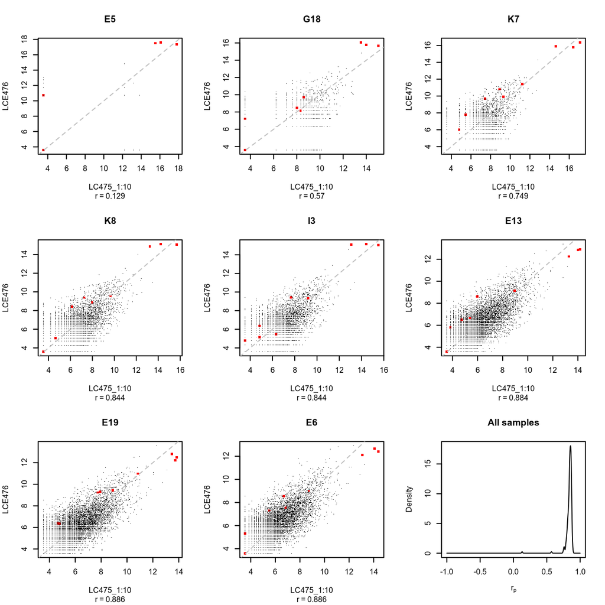

Figure 6: Association of UMI counts between batches for each gene within each sample. The first 8 panels are scatter plots of the UMI counts for each gene for the samples with the 3 lowest correlations, 2 middlemost correlations, and 3 highest correlations. The correlation in the scatterplot is reported below each panel. The final panel is the distribution of these correlations across all samples.

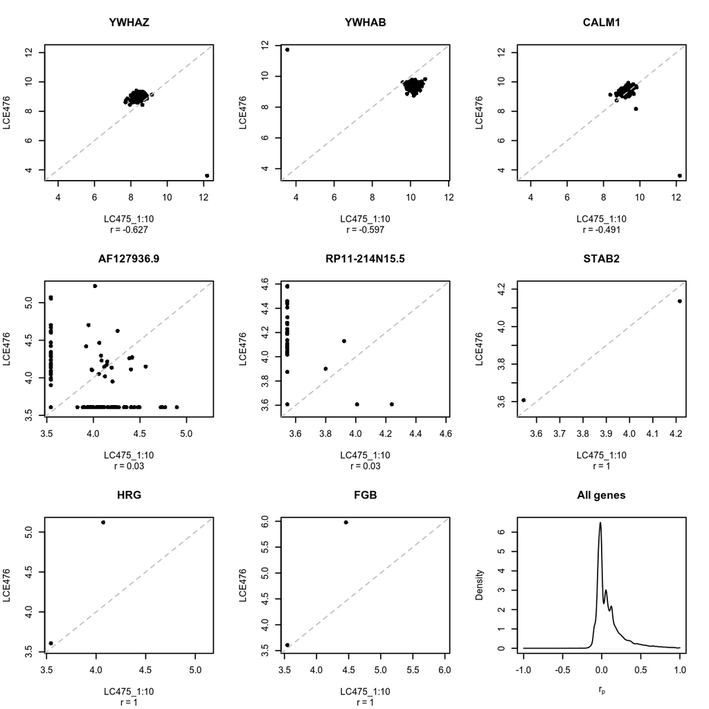

#### Sandbox

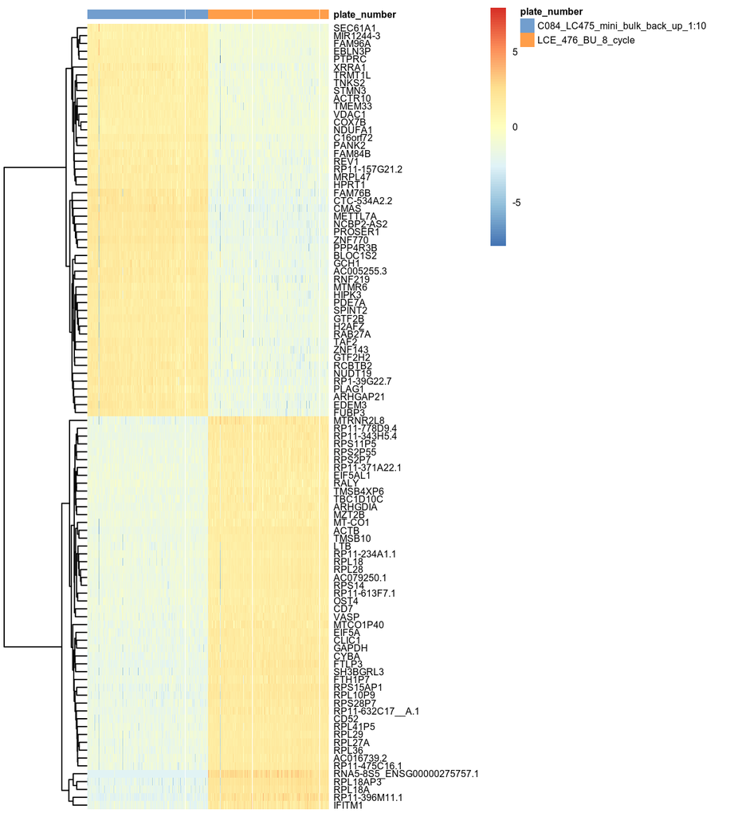

### Summary

**TODO** Write

[^1]: In the terminology of Bioconductor this is called a *SingleCellExperiment* object.
[^2]: Some care is taken to account for missing and duplicate gene symbols; missing symbols are replaced with the Ensembl identifier and duplicated symbols are concatenated with the (unique) Ensembl identifiers.
[^3]: The choice of a 6 bp UMI in the mini-bulk protocol is because it is adapted from SCORE’s CEL-Seq2 single-cell RNA-sequencing protocol. With scRNA-seq data it is very rare to observe more than $4^6 = 4096$ unique molecules for any one gene.